# wdnR: Introduction to Programming Using R

August 15 & 16, 2017

## Computer Programming for DNR Water Quality Professionals

### Day 1, the 'why' and 'how'

## Logistics

1. Download the course pack from:
   - //central/Water/WQWT_COMMON/Ruesch/r_workshop.zip
   - Or copy it from one of the available flash drives
   - Save it wherever you'd like and extract the contents of the zip file
2. Ensure RStudio and Excel are installed on your computer

## The plan for today

12:30 – 12:40: Welcome and Introductions

12:40 – 1:50: Why program?, using RStudio, and some R basics

1:50 – 1:55: BREAK

1:55 – 2:50: Data.frames and data types in R

2:50 – 2:55: BREAK

2:55 – 4:10: Subsetting data, making plots, and the dreaded “for-loop”

4:10 – 4:30: Flex time

4:30: Adjourn

## Why learn a computer programming language?

## Do you work on a computer?

If so, it's likely you could benefit in some way by learning a programming language.

## Using a computer without programming skills is like:

…advocating for water quality without understanding the science: you may be able to change the behavior of a few people with your persuasion alone, but you will be much more effective if you can properly communicate the implications of poor water quality, its causes, and the opportunities for restoration.

## Using a computer without programming skills is like:

…making pesto with a knife instead of a food processor: most of the time you're cutting each pine nut one at a time, and occasionally you can get a few all at once. With a food processor, it may take longer to set up, but once it's ready you can make a year's worth of pesto in 10 minutes and the result will be much more consistent.

## Using a computer without programming skills is like:

…making cake with a wheat seed and a baby chicken: rather than beginning from raw materials every time, it would be more effective to first raise many egg-producing chickens, replicate your wheat seed into a field of seed-yielding plants, and build a tool for processing seeds into flour.

## What is so special about the R language?

R will soon be the language preferred by most scientists. Measured by Google Scholar hits, R recently surpassed SAS, and will soon surpass SPSS which has been trending precipitously downward for the last 7 years.

## What is so special about the R language?

R is extremely extensible. It was originally designed to be used solely for data analysis and graphics. However, the scope of its use has increased dramatically to include automation, interactivity with other languages, application and web development, GIS, database management, and much more. The key is the involvement of a large (and growing) user base that contributes to the project.

## What is so special about the R language?

R is free

## R can do all sorts of amazing things

## Presentations

This slideshow brought to you by R!

[figure not shown]

## GIS

[figure not shown]

```r
d = data.frame(lat=43.074655, lon=-89.384218)
qmap("wisconsin state capitol", zoom=14) +
  geom_point(data=d, aes(x=lon, y=lat), size=10, pch=7, color="red")
```

## Online apps via Shiny

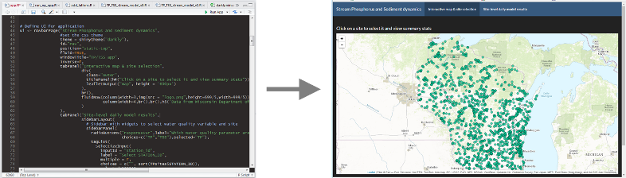

Online version of Alex's TP/TSS app

## Tour of RStudio

## Tour of RStudio

R comes in lots of different flavors, but the way that we will be using R for this class is through a software package called RStudio. RStudio packages many of the things you need to be a productive programmer all in place.

RStudio can help beginner programmers learn quickly, but it also has enough functionality to satisfy the advanced programmer as well.

To start, let's get a feel for the RStudio interface.

## Tour of RStudio

First, open RStudio software by clicking on the Windows Start button and typing "rstudio":

[figure not shown]

## Tour of RStudio

### how to set up your desktop for the class

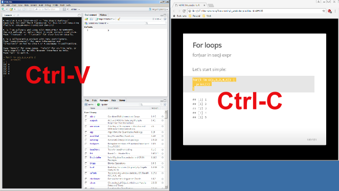

## Tour of RStudio

There are a number of windows in R, but we are going to start by using only one, the R **console**:

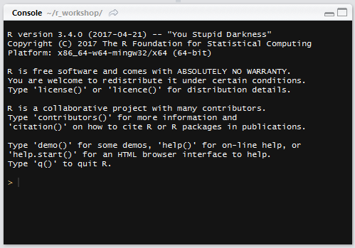

## Tour of RStudio

The R console allows you to type in R code interactively and print the result.

RStudio has many fancy functions, of which we will discuss in more detail as we go along, but basic R software (as opposed to RStudio) is essentially just the console, so you can mentally equate the R program with the mental image of the R console.

It's a commmand prompt (`>`, the place where you type in code), plain and simple.

## Tour of RStudio

Let's try writing our first line of code. One of the most basic elements of any computer programming language is simple math. Try typing in 2+2 at the command prompt, and hit enter:

```r
2+2
```

```
## [1] 4
```

## Tour of RStudio

Notice that the R console returns the result of that mathematical statement.

There is a little bracketed `[1]` next to the result–all that means is that first item is listed directly to the right–we will come back to this later, but for now you can ignore it.

## Exercise

Let's take 5 minutes to try out different mathematical statements. Try using different mathematical operators such as addition/subtraction (`+`, `-`), multiplication/division ( `*`, `/`), and exponents (`^`), and parentheses.

## Basic R Syntax

*[**sin**-taks]*

the rules/form of a computer programming language (e.g., characters, symbols, whitespace)

## Variables

When we type in a mathematical statement in the R console and press enter, it returns the results as a message printed on the screen.

As an alternative to having the result returned as a message, we can also save the result to be used later. We do this by **assigning** the result to a **variable**.

## Variables

To tell R to assign a value to a variable, We will use the equals sign (`=`):

```r
my_1st_variable = 5
```

## Variables

We can name the variable anything we want. Here I named it `my_1st_variable`, but I could just as well have named it `theodore_roosevelt`.

The only rule with naming variables is that it cannot contain a space, special characters, or start with a number.

## Variables

Think of a variable as a **container** that you can put anything into–you can also take things out or modify the contents, which is why they are called "variables".

Once the contents are stored, we can re-use them as though they have the same value as the contents themselves:

```r
my_1st_variable + 5
```

```
## [1] 10
```

## Variables

As you create more and more variables, RStudio has a helpful tool for you to keep track of them. There is a tab called "Environment" in the upper-right panel that lists all of your variables for you.

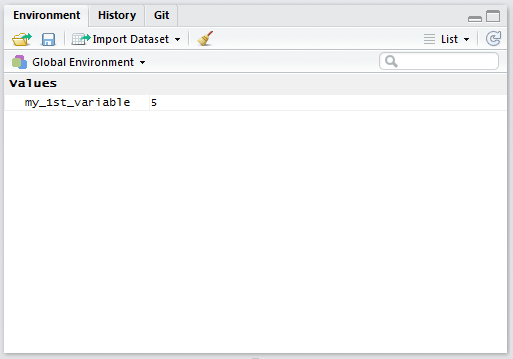

## Variables

In the same way we write mathematical equations, variables take on the value of the right-hand side of the equation. For example:

```r
x = 2 + 2
x + 2
```

```
## [1] 6
```

So what is the value of x?

## Variables

*Note: we can use either an equals sign (`=`) or an arrow (`<-`)–which is just the less-than sign followed by a hyphen–to assign a variable. If you want to bring the purist trolls out of the woodwork, ask Google which one you should use. If you want to keep it simple, just pick one and stick with it. In other words, it really doesn't matter which one you use, just be aware of both when reading other people's code*

## Exercise

Take 2-3 minutes to try out variable assignment using mathematical operators. Try re-using variables in mathematical statements.

## Scripts

You've probably begun to notice that it is tedious to write every statement of code, line-by-line, one-at-a-time, at the command prompt in the R console. Fortunately, you will not have to do this any longer. Enter the **script**.

A script contains many lines of code that can be executed simultaneously. It is a file stored on your hard drive, much like a .docx or .xlsx file, except it has a .r extension instead.

## Scripts

RStudio has a feature that makes it very easy to create a script. In the file menu, click new file, and then click R script. A new blank pane should appear:

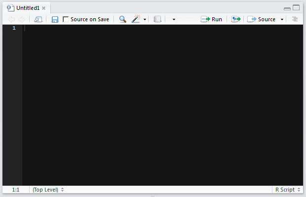

## Scripts

We are going to save this file on our hard drive, but first, a little house cleaning. We've set up an RStudio **project** for you, which is simply a way of containing many useful elements relating to a project in one place. In the file menu, click Open Project, navigate to the place you stored the course pack, and select the file called "r_workshop.Rproj". Doing so will set up our R session to work out of our course pack folder.

## Scripts

You can verify this by clicking the Files tab in the lower-right pane:

[figure not shown]

A window like the one above should appear with files associated with our class.

## Scripts

Now, let's save our R script.

First, type in a couple lines of code:

```r
x = 2 + 2
x + 2
```

## Scripts

Notice that RStudio recognizes certain characters and changes their colors. Although you are ultimately writing to a simple text file, because its file extension is ".r", RStudio recognizes that it contains R code, and then helps you visualize it through color.

## Scripts

One of the most useful features of the RStudio IDE is the ability to run the code in your scripts in your console. With your cursor on the same line as `x = 2 + 2`, press `Ctrl+Enter`.

## Scripts

Your scripts can also contain **comments** to help you and others understand your code. To add a comment, start with the hash symbol (`#`). Anything after `#` will not be executed until you start a new line.

```r
# This line is not executed
x = 2 + 2 # but this one is
```

As you are working through the course material, it may be helpful for you to write notes as comments.

## Exercise

Create a brand new script, write a few lines of code using variables and mathematical statements, and start getting in the habit of writing notes to yourself as `#comments`.

## Functions

One way to add 2 + 2:

```r
2+2
```

```
## [1] 4
```

Simple, but could get cumbersome with long sequences of numbers

Another way to add 2 + 2:

```r
sum(2,2)
```

```
## [1] 4
```

More flexible and concise method

## Functions

Sum is a **function**. An R function *does something*. It is an action statement. Functions are the **verbs** of computer programming.

The way we use functions in R is by typing their name followed by parentheses (without a space in between). The contents of the parentheses are called the **arguments**. Arguments are how we tell the function what to do. If "jump" were a function, the argument would by "how high?".

The arguments of the `sum` function are the values we want to add together. We separate arguments of a function with commas.

## Functions

So how do we know what arguments to use for each function? We can use R help for that. There are two ways to access help for R functions. The first is to use the RStudios help tab in the lower-right pane:

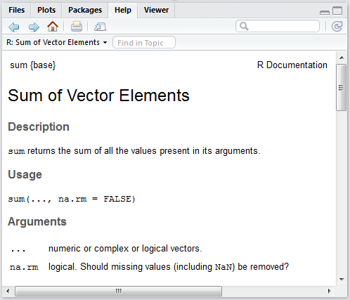

## Functions

Or, we can simply type a question mark followed by the function name in our console:

```r
?sum
```

## Functions

A core function in R that you will become very familiar with is the `c()` function. The `c()` function allows you to create a vector of values. A vector is a sequence of values:

```r
y = c(3,5,7)
print(y)
```

```
## [1] 3 5 7
```

Here, the `print()` function prints y in the console.

## Functions

In R, you can do math **across** vectors:

```r
z = y * 2
print(z)
```

```
## [1]  6 10 14
```

## Functions

This may not seem like much, but one of the most powerful aspects of R, and what sets it apart from many other computer programming languages is its ability to do math across sequences of numbers–it is what we refer to as an "array-based language".

## Exercise

Let's take 20 minutes to explore mathematical operators, variables, and functions. Try using vectors with other functions, such as the `mean()` and `stdev()` (standard deviation) functions.

## 5-MINUTE BREAK

## Data.frames

If you are accustomed to using Excel or Access, the data.frame object in R should be very intuitive for you. A data.frame is just a table of data.

In a data.frame, each column has a name and number that identify the data in it, and the data within a column is all the same type.

Before we use data.frames in R, let's look at the table that we'd like to use. Open the `Vilas_TP_CHL_data.csv` file in Excel (in the /data folder) and familiarize yourself with the data.

## Data.frames

Now we want to read that data into R. To do this, we will use the `read.csv` function. Remember, you can use the help menu to get details on how to use a function.

```r
?read.csv
```

For this function, the key argument is a `"text string"` representing the path to the file you're inputting.

All of the other arguments (`header`, `sep`, `nrows`, `skip`, etc.) have default values and are thus not required to be entered by the user. Default values are shown in the Usage section with an `=` sign: `read.csv(file,header=TRUE)`.

## Data.frames

Let's use what we've learned about read.csv to load in the data.frame

```r
d = read.csv("data/Vilas_TP_CHL_data.csv")
```

Notice how we give the file name and its location within the *data* folder? Because we are using an RStudio project, our `working directory` is the folder associated with the project - in this case, it is the *r_workshop* folder. So, our file path starting with "data/" tells R to look for a folder called *data* within *r_workshop*

## Data.frames

Once we have the data.frame read into R and saved as an object, we'll want to view it, check that the data were read in correctly, check column names, check numbers of rows and columns, etc. Since you don't always have a spreadsheet of the data in front of you, it's useful to become familiar with interpreting these attributes of your data. We can explore our data.frame in a few ways.

First, let's introduce a few useful functions. `str` (meaning "structure") is one you should become fluent in. For a data.frame, it only requires one argument: the name of your data.frame. Let's see the structure of our data.frame:

```r
str(d)
```

## Data.frames

```r
str(d)
```

```
## 'data.frame':    4213 obs. of  5 variables:
##  $ ID  : int  643401 643137 643137 643401 643402 643407 643080 643401 643137 643249 ...
##  $ NAME: Factor w/ 200 levels "Afterglow Lake - Deep Hole",..: 7 136 136 7 71 45 110 7 136 140 ...
##  $ DATE: Factor w/ 1541 levels "1993-05-12","1993-05-17",..: 1 2 3 4 5 6 7 8 8 8 ...
##  $ CHL : num  4.01 11.6 9.14 3.54 2.36 2.95 3.21 3.06 12.2 7.88 ...
##  $ TP  : num  11 39 23 9 20 9 13 10 30 16 ...
```

There are a few useful outputs: the number of observations (rows) and variables (columns), the name of each column, whether each column is numeric, integer, etc. (more on data.types next), and the first several entries of each column.

## Data.frames

Sometimes, it's easier to just look at the data.frame in table form though. To do that, we can just run `print(d)` or `d` for short. This will print the data.frame in the console, but gets messy if you have more than a few rows or columns.

One way to get around that is to use `head` or `tail` which only show you the top or bottom of your data.frame, but can still be messy if we have many columns.

```r
head(d)
```

```
##       ID                         NAME       DATE   CHL TP
## 1 643401       Anvil Lake - Deep Hole 1993-05-12  4.01 11
## 2 643137 Muskellunge Lake - Deep Hole 1993-05-17 11.60 39
## 3 643137 Muskellunge Lake - Deep Hole 1993-06-15  9.14 23
## 4 643401       Anvil Lake - Deep Hole 1993-06-21  3.54  9
## 5 643402      Harris Lake - Deep Hole 1993-06-28  2.36 20
## 6 643407        Crab Lake - Deep Hole 1993-06-29  2.95  9
```

## Data.frames

Finally, RStudio has another nice feature that lets us view our data.frame a little more like a spreadsheet - just double-click on the name of your data.frame in the Environment window or use `View(df)`.

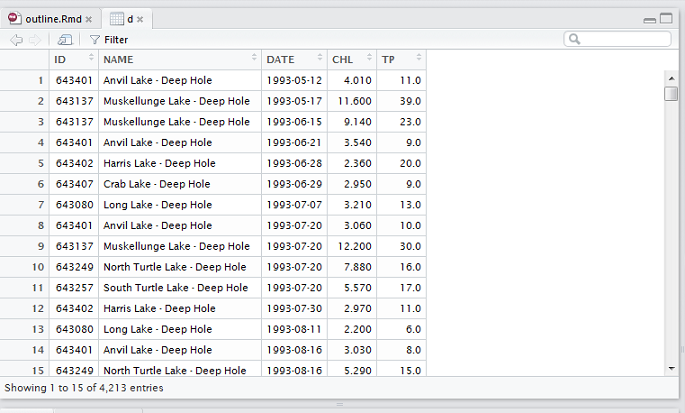

## Data.frames

If we just want to see the names of the variables, we can use `names` or `colnames`.

```r
colnames(d)
```

```
## [1] "ID"   "NAME" "DATE" "CHL"  "TP"
```

Finally, we may want some idea of how big our data.frame is. To get the number of rows, use `nrow`. For the number of columns, use `ncol`.

```r
nrow(d)
```

```
## [1] 4213
```

## Data.frames

What if we just want to look at a particular column? To access a particular column from a data.frame, we can use `$` in conjunction with the column name. Say we just want to look at the lake names in our dataset. We know that column is called "NAME". To access it, we use:

```r
d$NAME
```

```
##    [1] Anvil Lake - Deep Hole
##    [2] Muskellunge Lake - Deep Hole
##    [3] Muskellunge Lake - Deep Hole
##    [4] Anvil Lake - Deep Hole
##    [5] Harris Lake - Deep Hole
##    [6] Crab Lake - Deep Hole
##    [7] Long Lake - Deep Hole
##    [8] Anvil Lake - Deep Hole
##    [9] Muskellunge Lake - Deep Hole
##   [10] North Turtle Lake - Deep Hole
##   [11] South Turtle Lake - Deep Hole
##   [12] Harris Lake - Deep Hole
##   [13] Long Lake - Deep Hole
##   [14] Anvil Lake - Deep Hole
##   [15] North Turtle Lake - Deep Hole
```

[output cut: 4199 more lines]

## Exercise (5 min)

Run `read.csv` to load and name the TP & CHL data.frame. Try it with the other .csv files we've provided as well. Try using the `nrows` and `skip` arguments to read subsets of data. Verify data by viewing them, or using `str`, `head`, `tail`, `names`, `colnames`, `nrow`, and `ncol` functions. Access specific columns with `$`.

*Hint:* The arguments should be listed in the same order as they are in the help menu, unless you specifically set them with an equals (`=`) operator (e.g., "argument=___"). For example, the first argument to `read.csv` is the file—we can just enter the file first.

## Data.frames

### Organization

The way a `data.frame` is set up dictates how they can be used in analyses. The two general types of setups for tabular data are **wide** (or unstacked) and **long** (or stacked or tall). Generally, these are both more analysis-friendly than using multiple excel worksheets (one tab per lake, for instance).

### Wide data

Wide data.frames contain a separate column for each variable, so there is one row for each subject.

### Long data

In long data, each subject can have multiple rows - one for each separate sampling event, for instance.

## Data.frames

### Organization

Take a look at `d`. What format is it?

## Data.frames

### Organization

Take a look at `d`. What format is it?

**Long** data structures are generally more suitable for analyses than ***wide** data, because it is easier to reference a particular column (`TP`) than a set of columns (`2009_TP`, `2010_TP`…).

However, one downside of long data is that it is a little bit more difficult to access some summary types of information, like the number of stations in the dataset, or the sample size for each.

These are things we could do in an Excel pivot table. How can we do the same sorts of things in R?

## Data.frames

### Using long data.frames

One useful function is `unique`, which pulls out unique values. We can use it in conjunction with length (which counts the number of items in a vector) to get the number of stations, for instance.

```r
length(unique(d$ID))
```

```
## [1] 202
```

## Data.frames

### Using long data.frames

A little more advanced is the `table` function, which runs a cross-tabulation to count the number of observations (rows) for each factor. We can use this to get a table of sample sizes, assuming each row = 1 sample

```r
table(d$ID)
```

```
##
##   443409   643041   643042   643047   643050   643051   643053   643055
##       21       27       52       58       16       27        5       50
##   643058   643059   643062   643063   643064   643065   643066   643072
##       64       18        1        3        3        5       23        2
##   643074   643075   643077   643078   643080   643081   643082   643084
##       15       29       69       13       59       34       16       73
##   643085   643088   643089   643090   643094   643095   643097   643102
##        1       60       46        3       13       46        3       13
##   643104   643105   643106   643109   643111   643113   643114   643121
##       21       41       52       22        3       42       16       30
##   643123   643125   643126   643127   643132   643134   643135   643137
##        1       44       44        5       38        1        5       76
##   643140   643145   643146   643148   643160   643164   643165   643170
##       21       16       35        3        3       21       55       53
```

[output cut: 38 more lines]

## Data.frames

### Using long data.frames

Finally, the `aggregate` function allows you to pass other functions to subsets of the data.frame. For instance, we can calculate the mean TP for each station ID. You can think of the following code as "Pass the `mean` function to each set of TP values, where sets are defined by unique IDs"

```r
aggregate(d$TP,by=list(d$ID),mean)
```

```
##      Group.1         x
## 1     443409 27.714286
## 2     643041 26.429630
## 3     643042  9.825385
## 4     643047 14.262241
## 5     643050 34.912500
## 6     643051 30.381481
## 7     643053 45.600000
## 8     643055 17.504267
## 9     643058 16.215625
## 10    643059 30.805556
## 11    643062  9.000000
## 12    643063 29.666667
## 13    643064 13.333333
## 14    643065 20.200000
```

[output cut: 188 more lines]

## Exercise (5 min)

Use `length` and `unique` to figure out how many unique days sampling occurred on.

## Data Types

Let's say you are working in Excel, and you want to create a column that contains quantities of money associated with different people.

## Data Types

There are many data types in R, but in this section, we'll introduce 6 important types: numeric, integer, character, logical, factor, and date.

## Data Types

### Numbers

The two data types that represent numbers are "numeric" and "integer". A numeric data type is a quantity with a decimal point (sometimes referred to as "float" or "double" in other programming languages), and an integer is a quantity without a decimal point, simple as that! You can use the `class` function to query the data type of a value:

```r
class(1.5)
class(1)
```

```
## [1] "numeric"
## [1] "numeric"
```

## Data Types

### Numbers

Notice that value of 1 is defined as a numeric data type. If you want to be explicit about defining an integer, you must use a **coercion** function. Each data type has a coercion function–the name of the function is just the data type preceded by `as.`, such as `as.numeric` or `as.integer`.

```r
class(as.integer(1))
```

```
## [1] "integer"
```

## Data Types

### Characters

"Characters" (often referred to as "strings" in other programming languages) can include alphabet letters, digits, and special symbols, but are all treated as text. Characters can be defined by wrapping them in quotes:

```r
class("This is a character data type")
class("Numbers (1) and symbols ($) can be included in characters")
class("1")
```

```
## [1] "character"
## [1] "character"
## [1] "character"
```

## Data Types

### Characters

You can also coerce a value to a character using its coercion function:

```r
char_var = as.character(1.52342)
print(char_var)
```

```
## [1] "1.52342"
```

```r
class(char_var)
```

```
## [1] "character"
```

## Data Types

### Characters

When dealing with characters, likely the most common function that you will use is the `paste` function. The `paste` function concatenates character strings together:

```r
paste("a", "b", "c")
```

```
## [1] "a b c"
```

## Data Types

### Characters

Notice that the paste function separates each string with a space by default. To change the separation character, use the `sep` argument:

```r
paste("a", "b", "c", sep=",")
```

```
## [1] "a,b,c"
```

```r
paste("a", "b", "c", sep="")
```

```
## [1] "abc"
```

## Data Types

### Logical

"Logical" is the simplest data type because it can take only two values, TRUE and FALSE:

```r
class(TRUE)
```

```
## [1] "logical"
```

## Data Types

### Logical

The values TRUE and FALSE are only considered logical data type if written in these ways:

```r
# All caps
class(TRUE)
class(FALSE)
# Capital T or F
class(T)
class(F)
# 0 or 1
class(as.logical(0))
class(as.logical(1))
```

## Data Types

### Factors

Factors are a data type that describes *categories*. They are similar to character data types because they will appear the same when you print them, but they are different in how the data is stored in memory. It only makes sense to talk about factors when there is more than one, so let's explore a factor column in a `data.frame`.

## Data Types

### Factors

Remember that the `str` function can help us explore a `data.frame`:

```r
str(d)
```

```
## 'data.frame':    4213 obs. of  5 variables:
##  $ ID  : int  643401 643137 643137 643401 643402 643407 643080 643401 643137 643249 ...
##  $ NAME: Factor w/ 200 levels "Afterglow Lake - Deep Hole",..: 7 136 136 7 71 45 110 7 136 140 ...
##  $ DATE: Factor w/ 1541 levels "1993-05-12","1993-05-17",..: 1 2 3 4 5 6 7 8 8 8 ...
##  $ CHL : num  4.01 11.6 9.14 3.54 2.36 2.95 3.21 3.06 12.2 7.88 ...
##  $ TP  : num  11 39 23 9 20 9 13 10 30 16 ...
```

## Data Types

### Factors

Notice that the `NAME` column has 200 **levels**

```r
str(d$NAME)
```

```
##  Factor w/ 200 levels "Afterglow Lake - Deep Hole",..: 7 136 136 7 71 45 110 7 136 140 ...
```

This means there are 200 **unique** values.

## Data Types

### Factors

In a factor column, R assigns an **integer** to each unique value, or **level**:

```r
str(d$NAME)
```

```
##  Factor w/ 200 levels "Afterglow Lake - Deep Hole",..: 7 136 136 7 71 45 110 7 136 140 ...
```

## Data Types

### Factors

This storage strategy serves two purposes:

1. It consumes less memory. In most cases, character strings require more memory than integers.
2. It allows us to use character representations as a variable in a statistical model without using a character-to-integer lookup table.

## Data Types

### Dates

```r
str(d$DATE)
```

```
##  Factor w/ 1541 levels "1993-05-12","1993-05-17",..: 1 2 3 4 5 6 7 8 8 8 ...
```

```r
d$DATE = as.Date(d$DATE)
```

## `NA`, a special R value

There is a special value in R to denote "missing data". The value is `NA`. A couple things to know about `NA` values:

1. Doing math on vectors with **any** `NA` values will result in `NA` unless the `na.rm=TRUE` argument is specified (e.g., `sum(x, na.rm=TRUE)`)
2. `is.na` is a special function for finding `NA` values that will return `TRUE` for missing values and `FALSE` for anything else
3. Some R functions will smartly handle `NA` values and/or tell you how they've been handled, but others functions will handle them implicitly without telling you what they did. Use the help menu!

## Exercise

Take 5 minutes to test different functionality on different data types to see how R behaves (for example, try dividing an integer or multiplying by a character). Try integrating NA values into your expressions to test behavior.

## 5-MINUTE BREAK

## Slicing/Subsetting/Filtering

Our data is now stored in memory as a variable in R. However, we will likely need to do some further manipulation of our `data.frame`. A very common task is to slice/subset/filter (words that all mean the same thing) the data, which means that we will pull certain rows and/or columns from the full `data.frame`.

## Slicing/Subsetting/Filtering

The `subset` function selects certain rows from a `data.frame` based on whether a condition is met. It is very similar to using the "Filter" button in Excel:

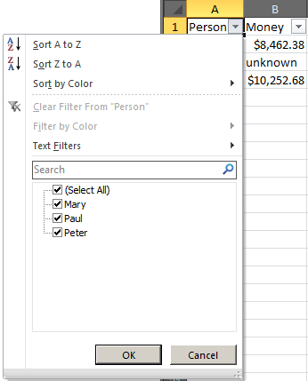

## Slicing/Subsetting/Filtering

There are two primary ways to slice/subset/filter:

1. By index
2. By condition

Let's try indexing first…

## Slicing/Subsetting/Filtering

### Indexing

Indexing defines the row or column number (i.e. the "index") to be selected. The syntax is square brackets with the indices of rows and columns contained in them, with row and column indices seperated by a comma:

```r
d[1,2]
```

```
## [1] Anvil Lake - Deep Hole
## 200 Levels: Afterglow Lake - Deep Hole ... Yellow Birch Lake at Max Depth
```

This statement selects the item in the 1st row and 2nd column

## Slicing/Subsetting/Filtering

### Indexing

To select all rows or columns, simply leave the bracketed position blank. This statement will select all columns in the first row

```r
d[1,]
```

```
##       ID                   NAME       DATE  CHL TP
## 1 643401 Anvil Lake - Deep Hole 1993-05-12 4.01 11
```

## Slicing/Subsetting/Filtering

### Indexing

To select a range of rows or columns, use the colon symbol. This statement will select the first five rows and first two columns:

```r
d[1:5,1:2]
```

```
##       ID                         NAME
## 1 643401       Anvil Lake - Deep Hole
## 2 643137 Muskellunge Lake - Deep Hole
## 3 643137 Muskellunge Lake - Deep Hole
## 4 643401       Anvil Lake - Deep Hole
## 5 643402      Harris Lake - Deep Hole
```

## Exercise (5 minutes)

Select the 10th through 50th rows of the `NAME` and `DATE` columns. **Extra credit:** try selecting a single column by *name* instead of by index. Try selecting *multiple* columns by name.

## Slicing/Subsetting/Filtering

### Condition

We can also subset using conditional statements. First, what is a conditional statement?

A conditional statement is a comparison that evaluates to either true or false.

We compare things using *logical operators*.

## Slicing/Subsetting/Filtering

### Condition

| Logical Operator | Definition |
| --- | --- |
| < | Less than |
| <= | Less than or equal to |
| > | greater than |
| >= | greater than or equal to |
| == | exactly equal to |
| != | not equal to |
| \| | logical "or" |
| & | logical "and" |

## Slicing/Subsetting/Filtering

### Condition

A silly axiomatic comparison:

```r
a = 2
print(a == 2)
```

```
## [1] TRUE
```

## Slicing/Subsetting/Filtering

### Condition

Multiple comparisons:

```r
print(d$TP < 30)
```

```
##    [1]  TRUE FALSE  TRUE  TRUE  TRUE  TRUE  TRUE  TRUE FALSE  TRUE  TRUE
##   [12]  TRUE  TRUE  TRUE  TRUE  TRUE  TRUE FALSE  TRUE  TRUE FALSE  TRUE
##   [23]  TRUE  TRUE  TRUE  TRUE  TRUE  TRUE  TRUE  TRUE  TRUE  TRUE  TRUE
##   [34]  TRUE  TRUE  TRUE  TRUE  TRUE  TRUE  TRUE  TRUE  TRUE  TRUE FALSE
##   [45]  TRUE  TRUE FALSE  TRUE  TRUE  TRUE  TRUE FALSE  TRUE FALSE  TRUE
##   [56]  TRUE  TRUE  TRUE  TRUE  TRUE  TRUE  TRUE  TRUE  TRUE  TRUE FALSE
##   [67]  TRUE  TRUE FALSE  TRUE FALSE  TRUE  TRUE  TRUE  TRUE  TRUE  TRUE
##   [78]  TRUE  TRUE FALSE  TRUE  TRUE  TRUE  TRUE  TRUE  TRUE  TRUE  TRUE
##   [89] FALSE  TRUE  TRUE  TRUE  TRUE  TRUE  TRUE  TRUE  TRUE  TRUE  TRUE
##  [100]  TRUE  TRUE  TRUE  TRUE  TRUE  TRUE  TRUE  TRUE  TRUE  TRUE  TRUE
##  [111]  TRUE  TRUE  TRUE  TRUE  TRUE  TRUE  TRUE  TRUE FALSE  TRUE FALSE
##  [122]  TRUE  TRUE  TRUE  TRUE  TRUE  TRUE  TRUE  TRUE  TRUE FALSE  TRUE
##  [133]  TRUE  TRUE  TRUE  TRUE  TRUE FALSE  TRUE  TRUE FALSE  TRUE  TRUE
##  [144]  TRUE  TRUE  TRUE  TRUE  TRUE  TRUE  TRUE  TRUE  TRUE FALSE  TRUE
##  [155]  TRUE  TRUE  TRUE  TRUE  TRUE  TRUE  TRUE  TRUE  TRUE  TRUE FALSE
```

[output cut: 368 more lines]

## Slicing/Subsetting/Filtering

### Condition

To slice/subset/filter using conditions instead of indexes, all you have to do is replace the index value in the square brackets with a conditional statement. R will return the rows/columns where the conditional statement evaluates to true.

This statement will select all columns, but only the rows where TP is greater than 40:

```r
d_sub = d[d$TP > 40,]
```

## Exercise (5 minutes)

Select all rows of `d` where TP has values between 10 and 40. **Extra credit:** Select all samples taken since 2007 that have TP values between 10 and 40.

## Scatterplots

- A HUGE benefit of R is its ability to produce customizable, complex, and downright pretty visualizations of data. A drawback of a 2-day workshop is that we can't quite teach you all of that.
- We can teach you the basics, which act as building blocks toward higher-level graphics.

## Scatterplots

We'll come back to making figures tomorrow, but by this point in the workshop, you've earned the right to see what the data look like outside of a data.frame. The key building block in making graphics is the `plot` function. This is a highly versatile function - it can take lots of different data and object types as inputs. The default usage is to just give it x and y coordinates in the form `plot(x,y)`, and it will output a scatterplot. In RStudio, this will show up in its own panel. The `x` and `y` arguments can be single values, vectors of values, or columns from a data.frame.

```r
plot(d$TP,d$CHL)
```

## Scatterplots

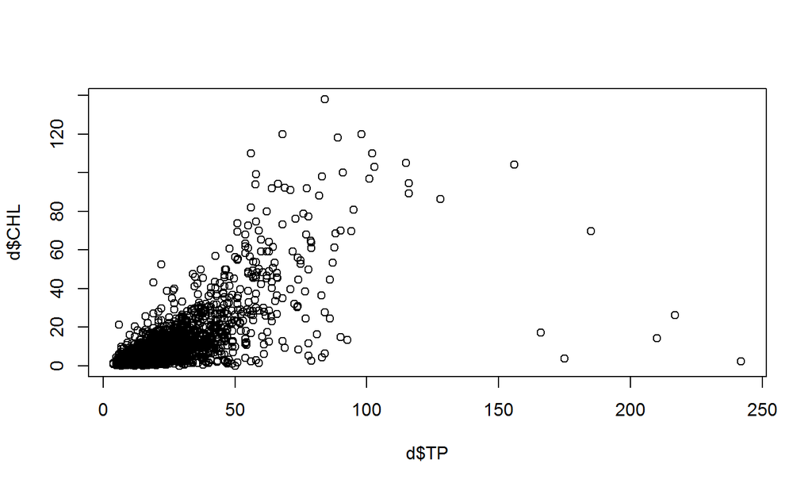

```r
plot(d$TP,d$CHL)
```

## Exercise (5 min)

Use your data.frame to play around with making simple scatterplots. Try to use subsetting to remake the plot for different lakes.

Try using some of the different plot arguments, if you have time. We'll come back to those tomorrow.

## For loops

Much of our work at DNR involves running the same general set of analytical steps on many units (e.g., monitoring stations, water bodies, permits, etc.). This can get a bit tedious, and is prone to error. Do you ever find yourself wondering, "If only I could program my computer to run these steps on all my sites, and then spend my time evaluating the results…"?

With `for` loops in R, you can!

A `for` loop automates a process by applying the same step(s) to one or more items. Related terms include "batch process" and "iterate".

## Control-flow constructs

- if(cond) expr
- if(cond) cons.expr else alt.expr
- for(var in seq) expr
- while(cond) expr
- repeat expr
- break
- next

## if statements

### if(cond) expr

- One of the key elements in complex programming
- Allows you to execute sections of code `if` one or more conditions are met

```r
if((2+2)==4) { # expr enclosed with {}
  print("Math is real!")
}
```

```
## [1] "Math is real!"
```

## For loops

### for(var in seq) expr

Let's start simple:

```r
s = c(1:5) # create seq
for(i in s) { # i for index
  print(i)
}
```

```
## [1] 1
## [1] 2
## [1] 3
## [1] 4
## [1] 5
```

What it does:

```r
i=1
print(i)
i=2
print(i)
i=3
print(i)
i=4
print(i)
i=5
print(i)
```

## For loops

### for(var in seq) expr

Now let's make `print` conditional on i not being 3:

```r
for(i in s) {
  if(i!=3) { # != means not equal
    print(i)
  }
}
```

```
## [1] 1
## [1] 2
## [1] 4
## [1] 5
```

## For loops: Best practices

### for(var in seq) expr

- Enclose `expr` in {}
- Test the loop on a short `seq`
- Factor out common operations rather than repeating them
- Vectorize slow `for` loops
- Include error handling code (e.g., break, next)
- Nested loops
  - Enclose each level in {}, and indent
  - Use a new `var` for each level

## Exercise

Write a `for` loop that prints the square roots of the numbers 4, 9, and 16.

Challenge: Write a `for` loop that prints the number of samples at each station in the Vilas dataset (d) if the number is >=6.

## One solution to the challenge exercise

```r
stations = unique(d$ID) # create vector of unique station IDs
for(s in stations) {
  n = nrow(d[d$ID==s,]) # number of samples at station s
  if(n>=6) print(paste("Station",s,"has",n,"samples"))
}
```

```
## [1] "Station 643401 has 113 samples"
## [1] "Station 643137 has 76 samples"
## [1] "Station 643402 has 12 samples"
## [1] "Station 643407 has 70 samples"
## [1] "Station 643080 has 59 samples"
## [1] "Station 643249 has 73 samples"
## [1] "Station 643257 has 69 samples"
## [1] "Station 643366 has 17 samples"
## [1] "Station 643412 has 11 samples"
## [1] "Station 643411 has 45 samples"
## [1] "Station 643109 has 22 samples"
## [1] "Station 643341 has 15 samples"
## [1] "Station 643077 has 69 samples"
## [1] "Station 643125 has 44 samples"
## [1] "Station 643237 has 49 samples"
```

[output cut: 104 more lines]

## For loops

Email from Dan Helsel to Matt Diebel regarding Dead Pike Lake clarity trends:

I saw Dr. Carpenter’s comment about “similar to trends I have seen in a lot of Northern Wisconsin lakes. Transparency increases after the 2006 drought, and decreases back toward historical values after 2012 or 2013.” So I started messing with the vilas and iron county secchi disk readings to see if I could “verify” his statement. …I’m wondering if there’s an easy way to select some lakes in those counties to see if we have similar trends. My adolescent ability to function within excel got me to the point of trying to graph seasonal trends on 50+ lakes (see sheet #2) – Aaaargh. Any suggestions or ideas?

## For loops

Prepare data

```r
data = read.csv("data/Vilas_County_Secchi_1995-2017.csv", as.is=TRUE)
data$Date = as.Date(data$Date, format="%m/%d/%Y")
data$Year = as.numeric(format(data$Date, "%Y"))
stations = aggregate(data$Date,
  by=list(data$StationID,data$StationName),
  FUN=length)
colnames(stations) = c("ID","NAME","COUNT")
stations = stations[stations$COUNT>=6,]
stations = stations[order(stations$NAME),]
xlims = c(min(data$Date), max(data$Date))
xgrid = as.Date(paste(c(399:403*5),"-01-01",sep=""))
```

## For loops

Put all plots into a single pdf

```r
pdf("plots/Vilas_County_Secchi_1995-2017_plots.pdf",
  width=8.5, height=11)
par(mfrow=c(3,2), oma=c(2,2,2,2))
for (s in 1:nrow(stations)) {
  sdata = data[data$StationID==stations$ID[s],]
  if(length(unique(sdata$Year))<10) {next}
  plot(Secchi~Date, sdata, type="n",
    xlab="", ylab="Secchi Depth (ft)",
    ylim=c(max(sdata$Secchi),0), xlim=xlims,
    main=paste(stations$ID[s]," - ",stations$NAME[s], sep=""),
    cex.main=0.9)
  abline(h=c(0:10*5), v=xgrid, col="lightgray")
  points(Secchi~Date, sdata)
  box()
}
dev.off()
```

## End of Day 1…BUT, just one more slide

## A note about closing RStudio

Every time you close RStudio, it will ask you if you want to save an RData file. An RData file saves all your variables (in memory) to a file (hard drive). This can be useful if you want to pick up where you left off at another time with all your variables read back into memory. Please save the RData file to your thumb drive.

Generally, it is MOST important to save your script. That is your main working document, and takes up very little storage space. You can always rerun the script the next time you work on a project.

## Computer Programming for DNR Water Quality Professionals

#### Day 2: the nitty gritty, so you can use R in your work!

## Logistics

1. Confirm that the course pack is still available,
   - Or download from
     - //central/Water/WQWT_COMMON/Ruesch/r_workshop.zip
   - Or copy it from one of the available flash drives
   - Save it wherever you'd like and extract the contents the zip file

## The plan for today

12:30 – 12:35: Welcome, Day 2 logistics

12:35 – 1:35: Detailed plotting

1:35 – 1:40: BREAK

1:40 – 3:00: Data analysis, management, and some show-and-tell

3:00 – 3:05: BREAK

3:05 – 4:10: Big exercise to bring it all together, share results

4:10 – 4:30: Q&A, and Flex time

4:30: Adjourn

## Get set up

Open RStudio

Click "File", then "Open Project" and find the **r_workshop.Rproj** file in the course pack.

Open outline.html slides

Open a new, blank script

## Logistics

### Picking up where we left off

Today, we'll start with a fresh script, and we'll try to keep it nicely organized. Start with this at the top of your script.

```r
###### READ IN MY DATA #######
model = read.csv("data/TP_CHL_models.csv")
d = read.csv("data/Vilas_TP_CHL_data.csv")
d$DATE = as.Date(d$DATE)
#####
```

In RStudio, lots of `#####`s (4 or more) wrapped around a title can be used to denote sections. You should be able to click the little down arrow next to the first line to collapse the whole section.

## More detailed plotting

Yesterday, we showed you how to make simple scatterplots. But, there are numerous other types of plots you can make, infinite ways to customize them, and some techniques for creating publication or web-quality figures. Today, we'll introduce you to a bit of all of the above.

## Other plot types

The basic `plot` command is versatile and can take various types of input arguments, but there are other functions. For instance, if you want to make a boxplot, then the `boxplot` command might suit you.

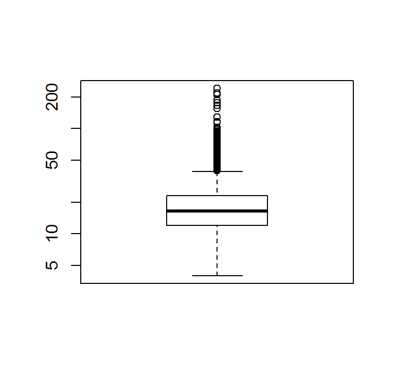

```r
boxplot(d$TP,log="y")
```

## Other plot types

Or using formula notation…

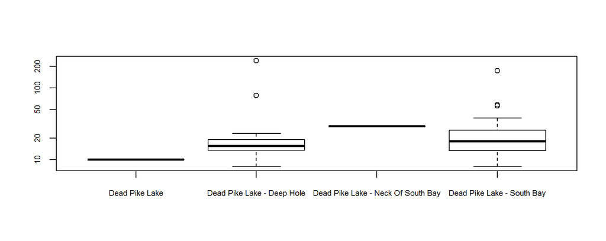

```r
#subset lakes to those w/ "Dead Pike" in name:
deadpike = d[grepl("Dead Pike",d$NAME),]
deadpike$NAME = factor(deadpike$NAME) #reset factors
boxplot(deadpike$TP~deadpike$NAME,log="y",cex.axis=0.7)
```

## Other plot types

If you want to make a histogram, `hist` will probably work.

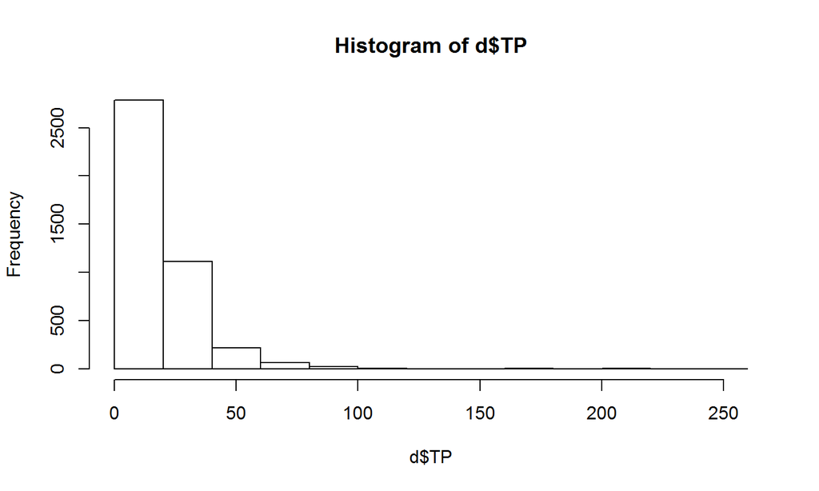

```r
hist(d$TP)
```

## Other plot types

These and many other functions exist, and they're not too hard to find. Just google them (e.g., "R histogram"). Feel free to try to find other plot types that you can make in R on your own.

## Customizing plots

For now though, let's go back to our basic scatterplot and learn how to customize it (aka, add complexity and make it pretty).

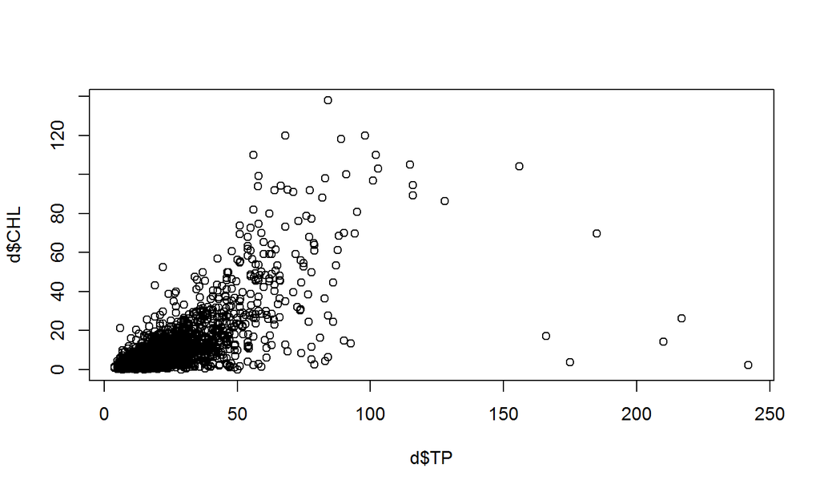

```r
plot(d$TP,d$CHL)
```

## Customizing plots

For simplicity, let's limit it to one lake:

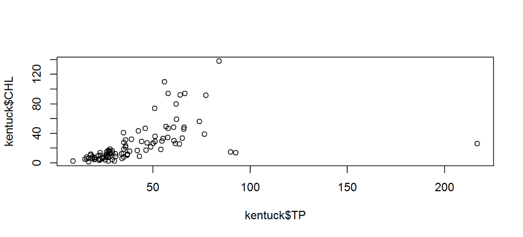

```r
kentuck = d[d$NAME=="Kentuck Lake - Site 2-East End-Deep Hole",]
plot(kentuck$TP,kentuck$CHL)
```

## Customizing plots

First, let's say we want to make a scatterplot with an overlayed line that compares our points to an existing model. The general approach in R is to first create your simple plot, and then add features to it. You can add features with a number of functions, including `lines`, `points`, `polygon`, and more. These don't create plots on their own - they add lines, points, or a polygon to a plot that has already been made and is currently active.

For our example, we'll use the 2nd data.frame from our project folder, which already has modeled chlorophyll as a function of TP. The units are log-transformed though, so we'll untransform using `exp`.

```r
plot(kentuck$TP,kentuck$CHL)
lines(exp(model$logTP),exp(model$fit))
```

## Customizing plots

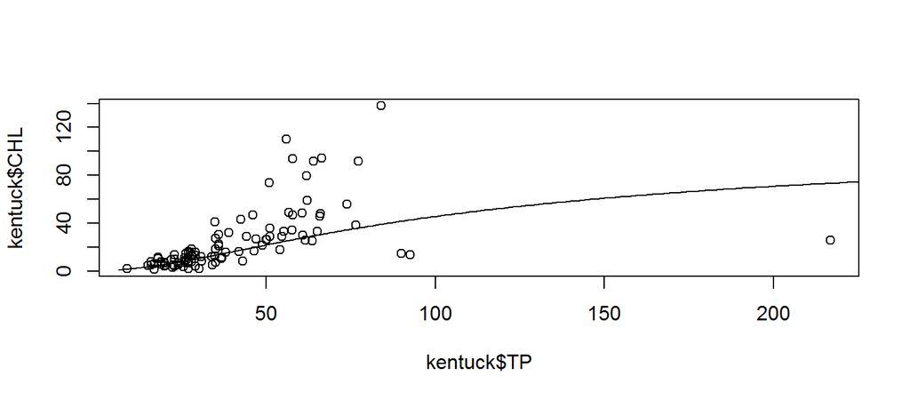

```r
plot(kentuck$TP, kentuck$CHL)
lines(exp(model$logTP), exp(model$fit))
```

Great, now you have 2 layers! 'Tis a shame that it's pretty ugly! Let's spruce it up!

## Customizing plots

You may have noticed that in the `plot` help file, there are many arguments, including `xlab` and `ylab` to name your axes and `main` for the plot title. These arguments require text strings:

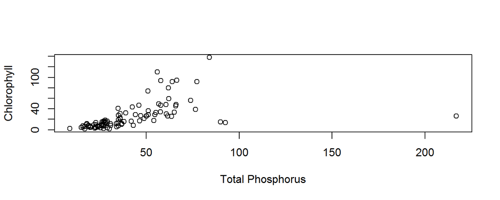

```r
plot(kentuck$TP,kentuck$CHL,
     xlab="Total Phosphorus",
     ylab="Chlorophyll",
     main="") #this makes sure that the title is left blank
```

## Customizing plots

Then, in the help files for `plot`, `lines`, etc., there is something called "Further graphical parameters (see par)…". `par` is essentially a set of default parameters. Use `?par` to see the numerous options. We won't walk through them all now, but they are worth exploring. Many of them can be changed within the `plot` command. Let's take a look at some common ones

## Customizing plots

| argument | description | example |
| --- | --- | --- |
| log | log-transform axes? | log="x" |
| col | symbol color | col="blue" |
| bg | background color of a symbol | bg="skyblue" |
| pch | dot type | pch=21 |
| cex | text and symbol size (relative to 1) | cex=1.5 |
| lty | line type | lty=2 |
| lwd | line width | lwd=3 |
| las | axis label direction | las=1 |

## Customizing plots

Let's first use the `log` argument to log both axes.

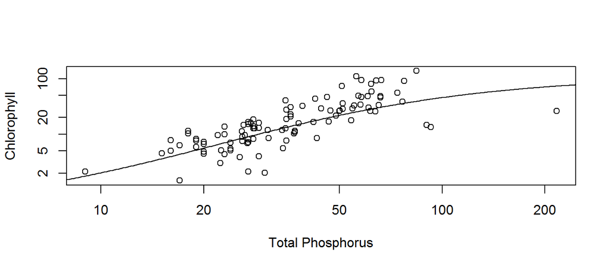

```r
plot(kentuck$TP,kentuck$CHL,
     log="xy", #transforms both axes into log-scale
     xlab="Total Phosphorus",ylab="Chlorophyll",main="")
lines(exp(model$logTP),exp(model$fit))
```

## Customizing plots

Now, let's change the point and line types. A simple way to find what types are available is to google "r pch" or "r lty".

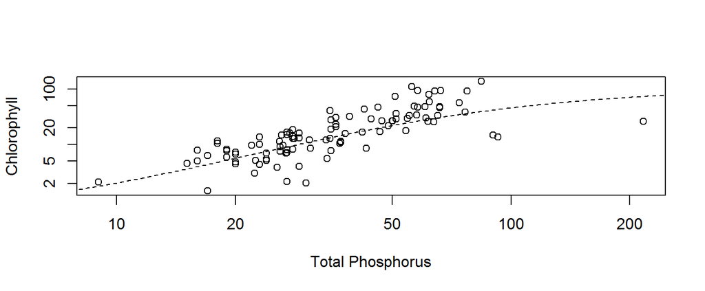

```r
plot(kentuck$TP,kentuck$CHL,log="xy",
     pch=21,
     xlab="Total Phosphorus",ylab="Chlorophyll",main="")
lines(exp(model$logTP),exp(model$fit),
      lty=2)
```

## Customizing plots

Now, add some color. Colors can be pretty intuitive ("black","red", etc.). You can also google image "r colors" to see pre-named colors, or you can provide RGB codes in the form "#RRGGBB", or use existing color palettes and functions (e.g. (rainbow).

```r
plot(kentuck$TP,kentuck$CHL,log="xy",pch=21,
     col="seagreen",bg="seagreen1",
     xlab="Total Phosphorus",ylab="Chlorophyll",main="")
lines(exp(model$logTP),exp(model$fit),lty=2,
      col="seagreen4")
```

## Customizing plots

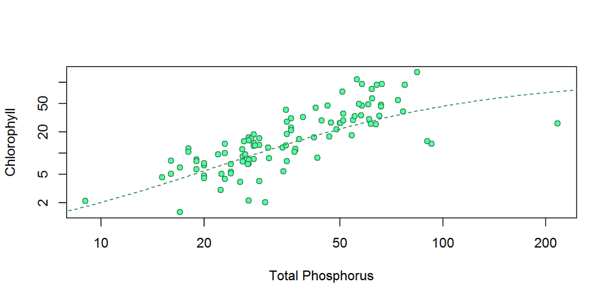

```r
plot(kentuck$TP,kentuck$CHL,log="xy",pch=21,
     col="seagreen",bg="seagreen1",
     xlab="Total Phosphorus",ylab="Chlorophyll",main="")
lines(exp(model$logTP),exp(model$fit),lty=2,
      col="seagreen4")
```

## Customizing plots

Now, let's increase the dot size and line thickness

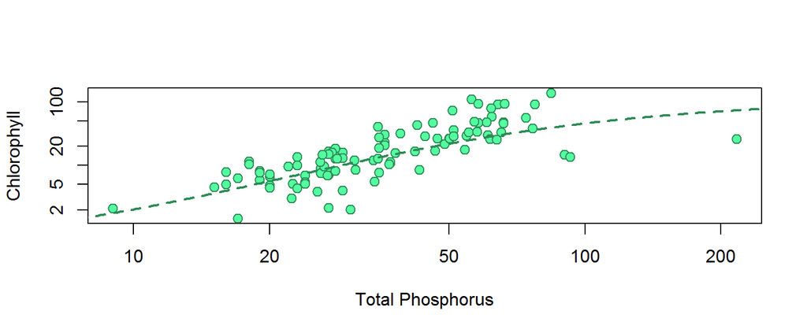

```r
plot(kentuck$TP,kentuck$CHL,pch=21,col="seagreen",bg="seagreen1",
     cex=1.2,
     xlab="Total Phosphorus",ylab="Chlorophyll",main="",log="xy")
lines(exp(model$logTP),exp(model$fit),lty=2,col="seagreen4",
      lwd=2)
```

## Customizing plots

Change the orientation of the axis-tick labels (so they all read left-to-right)

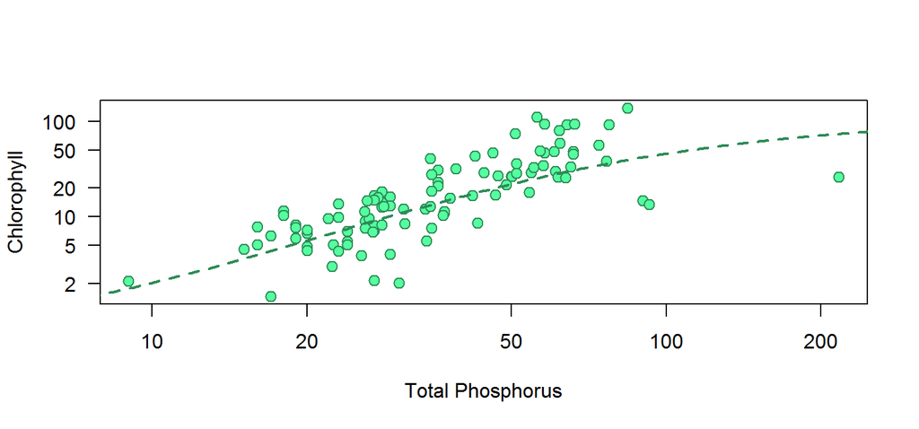

```r
plot(kentuck$TP,kentuck$CHL,pch=21,col="seagreen",bg="seagreen1",cex=1.2,
     las=1,
     xlab="Total Phosphorus",ylab="Chlorophyll",main="",log="xy")
lines(exp(model$logTP),exp(model$fit),lty=2,col="seagreen4",lwd=2)
```

## Customizing plots

Now, let's finally try to get rid of that useless white space at the top of our plot. To do that, we'll introduce a new way to control `par` settings.

There are some arguments that can only be set in a specific call to the `par` function, instead of within `plot`. `mar` is an argument thats takes a vector of 4 values, where each is the number of lines of space provided on each side of the plot in the form c(bottom, left, top, right). The default is c(5.1,4.1,4.1,2). So, R is providing 4.1 lines of space above the plot (the 3rd value in that vector). To reduce that to something small, we just reset its value in par: `par(mar=c(5.1,4.1,0.5,2))`.

## Customizing plots

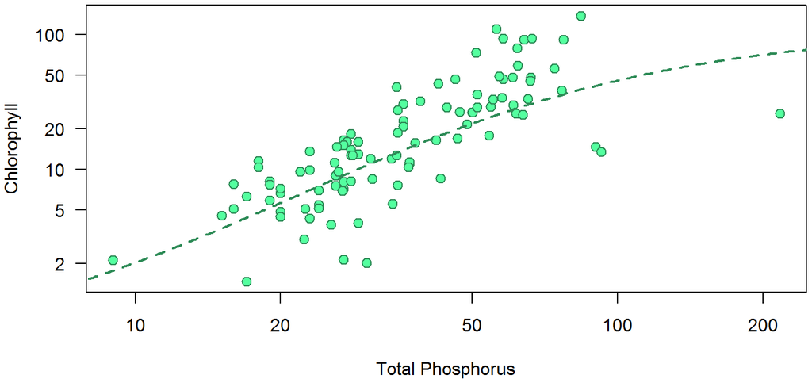

```r
par(mar=c(4,4,0.25,0.25))
plot(kentuck$TP,kentuck$CHL,pch=21,col="seagreen",bg="seagreen1",
     cex=1.2,las=1,xlab="Total Phosphorus",
     ylab="Chlorophyll",main="",log="xy")
lines(exp(model$logTP),exp(model$fit),lty=2,col="seagreen4",lwd=2)
```

## Customizing plots

One of the things that `par` allows us to do is multi-panel plotting. Perhaps you noticed that each time you ran the `plot` function, the previous plot was overwritten. What if you wanted two plots on the same figure, next to each other? Before creating the first plot, we can use `par` to tell R that we're going to create 2 plots in the figure. There are two `par` arguments that control this: `mfrow` and `mfcol`. I think of the "mf" as "multiple figures" and "col" or "row" to indicate the number of columns or rows, respectively, and how many items in each one. Thus, `par(mfrow=c(3,2))` creates a 6-panel plot with 3 rows of 2 items (columns) each. To make two plots side-by-side, we can use `par(mfrow=c(1,2))`.

## Customizing plots

```r
#first make a data.frame for a different lake to plot in the 2nd panel
sTwin = d[d$NAME=="South Twin Lake - Deep Hole",]

#set up our plot

par(mar=c(4,4,.3,.3),
  mfrow=c(1,2))
plot(kentuck$TP,kentuck$CHL,pch=21,col="seagreen",bg="seagreen1",
     cex=1.2,las=1,xlab="Total Phosphorus",
     ylab="Chlorophyll",main="",log="xy")
lines(exp(model$logTP),exp(model$fit),lty=2,col="seagreen4",lwd=2)

plot(sTwin$TP,sTwin$CHL,pch=21,col="seagreen",bg="seagreen1",
     cex=1.2,las=1,xlab="Total Phosphorus",
     ylab="Chlorophyll",main="",log="xy")
lines(exp(model$logTP),exp(model$fit),lty=2,col="seagreen4",lwd=2)
```

## Customizing plots

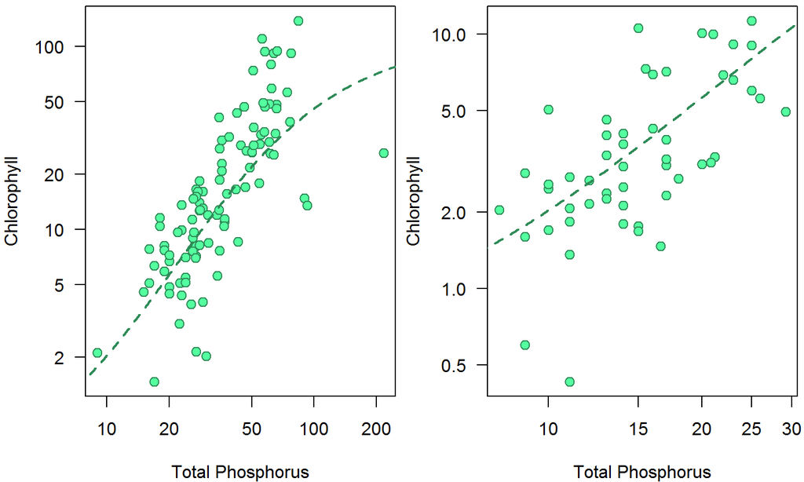

## Customizing plots

Let's improve this plot by doing 2 things to make it easier to compare between lakes

1. Set the axis limits so that they are equal between the two plots
2. Add a label identifying each lake

## Customizing plots

To set the axis limits, we can use the arguments `xlim` and `ylim` in conjunction with the `range` function to find the min and max.

```r
xlimits = range(c(kentuck$TP,sTwin$TP))
ylimits = range(c(kentuck$CHL,sTwin$CHL))
```

## Customizing plots

```r
par(mfrow=c(1,2),mar=c(4,4,.3,.3))
plot(kentuck$TP,kentuck$CHL,pch=21,col="seagreen",bg="seagreen1",cex=1.2,
     xlim=xlimits,ylim=ylimits,
     las=1,xlab="Total Phosphorus",ylab="Chlorophyll",main="",log="xy")
lines(exp(model$logTP),exp(model$fit),lty=2,col="seagreen4",lwd=2)

plot(sTwin$TP,sTwin$CHL,pch=21,col="seagreen",bg="seagreen1",cex=1.2,
     xlim=xlimits,ylim=ylimits,
     las=1,xlab="Total Phosphorus",ylab="Chlorophyll",main="",log="xy")
lines(exp(model$logTP),exp(model$fit),lty=2,col="seagreen4",lwd=2)
```

## Customizing plots

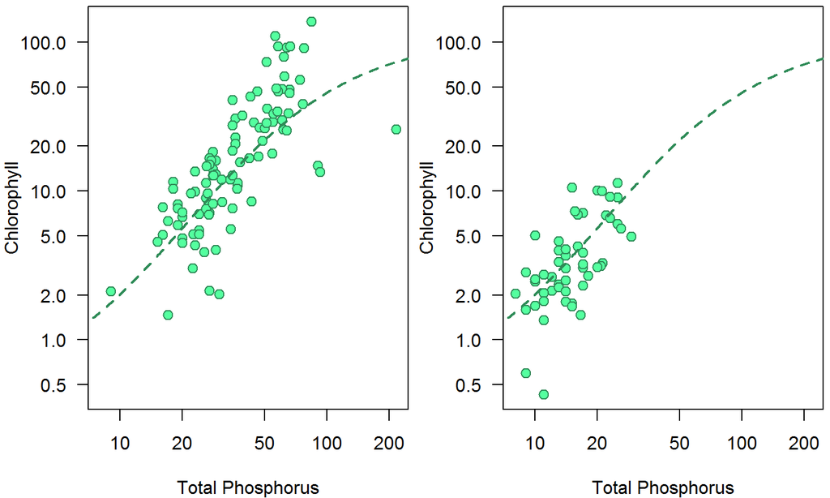

## Customizing plots

We could easily add Lake Name labels with the `main` argument in `plot`. However, in this case we'd prefer to have the lake names in the upper left space within the plots.

To do this, we can use the `text` or `legend` function. These work like `lines` in that they plot onto an active graphic. For `text`, you supply the x & y coordinates where the text should go, and the text itself. In this case, we'll use `legend` to take advantage of its use of location keywords (e.g., "topleft").

```r
legend("topleft", #give the location by keyword
       "Kentuck Lake", #the contents of the legend
       bty="n") #bty means box type around legend, "n" means none
```

## Customizing plots

```r
par(mfrow=c(1,2),mar=c(4,4,.3,.3))
plot(kentuck$TP,kentuck$CHL,pch=21,col="seagreen",bg="seagreen1",
     cex=1.2,las=1,xlim=xlimits,ylim=ylimits,
     xlab="Total Phosphorus",ylab="Chlorophyll",main="",log="xy",)
lines(exp(model$logTP),exp(model$fit),lty=2,col="seagreen4",lwd=2)
legend("topleft","Kentuck Lake",bty="n")

plot(sTwin$TP,sTwin$CHL,pch=21,col="seagreen",bg="seagreen1",
     cex=1.2,las=1,xlim=xlimits,ylim=ylimits,
     xlab="Total Phosphorus",ylab="Chlorophyll",main="",log="xy")
lines(exp(model$logTP),exp(model$fit),lty=2,col="seagreen4",lwd=2)
legend("topleft","South Twin Lake",bty="n")
```

## Customizing plots

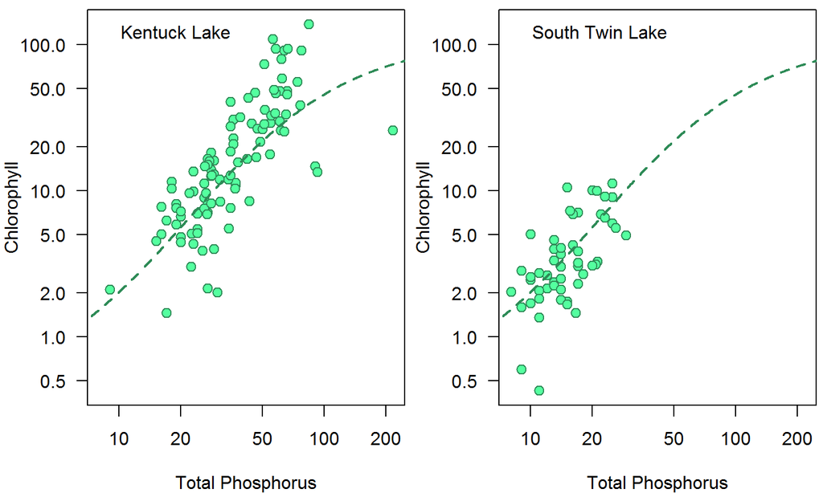

## Saving plots

Finally, what if we want to save our plot outside of R? The recommended strategy is to use a graphic devices function, which give you full control over dimensions, resolution, background color, etc. The functions are named pretty intuitively: `pdf`, `png`, `jpeg`, `tiff`, etc.

Key arguments: `filename`, `width`, `height`, `units`, and `res`

- `units` can be "px" (default), "in", "cm", or "mm". I generally use "in", as these are typically easy to fit onto a slide or a page. Then, you can set `width` and `height` to desired dimensions (width=6, height=4).
- `res` defines the dots/pixels per inch for bitmap type images. Generally, 150 is sufficient for presentations, 300 is good for print, but some publications require higher.
- `filename` is your desired file name and extension

## Saving plots

Example:

```r
png("MyNewFigure.png",
    units="in",
    width=6.5, #sized for paper width between margins
    height=3.5,
    res=300)
```

## Saving plots

So how do you get that function to work with your plotting code?

When you run `png`, nothing seems to happen in RStudio. However, behind the scenes, R opens a new graphical device, onto which all the subsequent lines of code will be run and plotted. At the end of those lines of code, we need to tell R to stop the plotting and save the .png file. We can do this by telling R to shut off the graphical device. We do that by running `dev.off`. Let's see how all this comes together to create and save a figure…

## Saving plots

```r
png("MyNewFigure.png",units="in",width=6.5,height=3.5,res=300)
par(mfrow=c(1,2),mar=c(4,4,.3,.3))
plot(kentuck$TP,kentuck$CHL,pch=21,col="seagreen",bg="seagreen1",
     cex=1.2,las=1,xlim=xlimits,ylim=ylimits,
     xlab="Total Phosphorus",ylab="Chlorophyll",main="",log="xy",)
lines(exp(model$logTP),exp(model$fit),lty=2,col="seagreen4",lwd=2)
legend("topleft","Kentuck Lake",bty="n")

plot(sTwin$TP,sTwin$CHL,pch=21,col="seagreen",bg="seagreen1",
     cex=1.2,las=1,xlim=xlimits,ylim=ylimits,
     xlab="Total Phosphorus",ylab="Chlorophyll",main="",log="xy")
lines(exp(model$logTP),exp(model$fit),lty=2,col="seagreen4",lwd=2)
legend("topleft","South Twin Lake",bty="n")
dev.off()
```

## Saving plots

You should now be able to find your saved figure in the project folder. Open it to see what it looks like. Note that the sizing of items may not match the way RStudio showed it to you.

[figure not shown]

## Exercise (20 min)

Play around with creating and customizing prettier plots in R. Try all the settings we demo'd: colors, point and line types, point sizes and line widths, margin sizes, multipanel plots, and saving options.

To go above and beyond, try out some new plot types or plotting arguments in `par`! Remember, google is your friend!

If there's something you want to change but can't seem to figure out how, let us know! There's always a way!

Whoever makes the prettiest plot wins! (By entirely subjective standards, of course)

## 5-MINUTE BREAK

## Data analysis with R

So far, we've presented the basics of using R, and gone into some depth in exploring plots, which are a natural early step in data analysis. R is also a powerful statistical platform. Base R includes most basic statistical functions. There are also R packages for pretty much any statistical method you have heard of, from mixed effects models, to classification and regression trees, to ordination, to artificial neural networks, and many more…

In this workshop, we will demonstrate the use of a few common statistical methods, including setting up the data frame, writing the model formula, and working with the results. This is not a statistics course, so we won't cover the appropriate uses of these methods.

## Data format

Most statistical functions require that your data be formatted as a data frame with variable names as column names. Let's use the `kentuck` data frame for the example.

```r
str(kentuck)
```

```
## 'data.frame':    102 obs. of  5 variables:
##  $ ID  : int  643451 643451 643451 643451 643451 643451 643451 643451 643451 643451 ...
##  $ NAME: Factor w/ 200 levels "Afterglow Lake - Deep Hole",..: 81 81 81 81 81 81 81 81 81 81 ...
##  $ DATE: Date, format: "1999-07-19" "2000-09-25" ...
##  $ CHL : num  11 9 1.47 13.6 7.02 5.08 7.13 15.7 16.1 8.08 ...
##  $ TP  : num  37 26 17 23 24 16 27 38 29 27 ...
```

## Regression

`lm()` (linear model) is the basic regression function. The required arguments are formula and data.

In `lm()`, the model formula specifies the response and predictor variable(s), any interactions among predictors, and may include variable transformations.

For example,

```r
model1 = lm(log(CHL)~log(TP),kentuck)
```

will fit a regression between log(TP) and log(CHL) for Kentuck Lake and assign the resulting model object to the variable `model1`.

## Regression

### model object

You can print a summary of the model results with

```r
summary(model1)
```

```
##
## Call:
## lm(formula = log(CHL) ~ log(TP), data = kentuck)
##
## Residuals:
##      Min       1Q   Median       3Q      Max
## -2.11606 -0.30693  0.07508  0.38441  1.30374
##
## Coefficients:
##             Estimate Std. Error t value Pr(>|t|)
## (Intercept)  -2.4941     0.4467  -5.583 2.04e-07 ***
## log(TP)       1.4634     0.1239  11.809  < 2e-16 ***
## ---
## Signif. codes:  0 '***' 0.001 '**' 0.01 '*' 0.05 '.' 0.1 ' ' 1
##
## Residual standard error: 0.6282 on 100 degrees of freedom
## Multiple R-squared:  0.5824, Adjusted R-squared:  0.5782
## F-statistic: 139.5 on 1 and 100 DF,  p-value: < 2.2e-16
```

## Regression

### model object

`model1` is an object of class "lm", which contains all the model results in a list format.

```r
str(model1)
```

```
## List of 12
##  $ coefficients : Named num [1:2] -2.49 1.46
##   ..- attr(*, "names")= chr [1:2] "(Intercept)" "log(TP)"
##  $ residuals    : Named num [1:102] -0.3924 -0.0767 -1.2669 0.5156 -0.208 ...
##   ..- attr(*, "names")= chr [1:102] "466" "602" "680" "781" ...
##  $ effects      : Named num [1:102] -27.576 7.419 -1.226 0.554 -0.17 ...
##   ..- attr(*, "names")= chr [1:102] "(Intercept)" "log(TP)" "" "" ...
##  $ rank         : int 2
##  $ fitted.values: Named num [1:102] 2.79 2.27 1.65 2.09 2.16 ...
##   ..- attr(*, "names")= chr [1:102] "466" "602" "680" "781" ...
##  $ assign       : int [1:2] 0 1
##  $ qr           :List of 5
##   ..$ qr   : num [1:102, 1:2] -10.1 0.099 0.099 0.099 0.099 ...
##   .. ..- attr(*, "dimnames")=List of 2
##   .. .. ..$ : chr [1:102] "466" "602" "680" "781" ...
##   .. .. ..$ : chr [1:2] "(Intercept)" "log(TP)"
##   .. ..- attr(*, "assign")= int [1:2] 0 1
##   ..$ qraux: num [1:2] 1.1 1.06
##   ..$ pivot: int [1:2] 1 2
##   ..$ tol  : num 1e-07
##   ..$ rank : int 2
##   ..- attr(*, "class")= chr "qr"
##  $ df.residual  : int 100
##  $ xlevels      : Named list()
##  $ call         : language lm(formula = log(CHL) ~ log(TP), data = kentuck)
##  $ terms        :Classes 'terms', 'formula'  language log(CHL) ~ log(TP)
##   .. ..- attr(*, "variables")= language list(log(CHL), log(TP))
##   .. ..- attr(*, "factors")= int [1:2, 1] 0 1
##   .. .. ..- attr(*, "dimnames")=List of 2
##   .. .. .. ..$ : chr [1:2] "log(CHL)" "log(TP)"
##   .. .. .. ..$ : chr "log(TP)"
##   .. ..- attr(*, "term.labels")= chr "log(TP)"
##   .. ..- attr(*, "order")= int 1
##   .. ..- attr(*, "intercept")= int 1
##   .. ..- attr(*, "response")= int 1
##   .. ..- attr(*, ".Environment")=<environment: R_GlobalEnv>
##   .. ..- attr(*, "predvars")= language list(log(CHL), log(TP))
##   .. ..- attr(*, "dataClasses")= Named chr [1:2] "numeric" "numeric"
##   .. .. ..- attr(*, "names")= chr [1:2] "log(CHL)" "log(TP)"
##  $ model        :'data.frame':   102 obs. of  2 variables:
##   ..$ log(CHL): num [1:102] 2.398 2.197 0.385 2.61 1.949 ...
##   ..$ log(TP) : num [1:102] 3.61 3.26 2.83 3.14 3.18 ...
##   ..- attr(*, "terms")=Classes 'terms', 'formula'  language log(CHL) ~ log(TP)
##   .. .. ..- attr(*, "variables")= language list(log(CHL), log(TP))
##   .. .. ..- attr(*, "factors")= int [1:2, 1] 0 1
##   .. .. .. ..- attr(*, "dimnames")=List of 2
##   .. .. .. .. ..$ : chr [1:2] "log(CHL)" "log(TP)"
##   .. .. .. .. ..$ : chr "log(TP)"
##   .. .. ..- attr(*, "term.labels")= chr "log(TP)"
##   .. .. ..- attr(*, "order")= int 1
##   .. .. ..- attr(*, "intercept")= int 1
##   .. .. ..- attr(*, "response")= int 1
##   .. .. ..- attr(*, ".Environment")=<environment: R_GlobalEnv>
##   .. .. ..- attr(*, "predvars")= language list(log(CHL), log(TP))
##   .. .. ..- attr(*, "dataClasses")= Named chr [1:2] "numeric" "numeric"
##   .. .. .. ..- attr(*, "names")= chr [1:2] "log(CHL)" "log(TP)"
##  - attr(*, "class")= chr "lm"
```